# 第2回 記述統計と集団平均の変動

経済プログラミング特論II

第2回

記述統計と集団平均の変動

同じ平均でも、中身と確かさは違う

経済プログラミング特論II

第2回 — Topic01

記述統計と分布の形状

平均が同じでも、中身は違う

## 今日の道のり

1

中身を見る

演習 1-1・1-2

ヒストグラムとずれ

2

揺れを測る

演習 2-1・2-2

件数と標準誤差

3

消えない揺れ

演習 3-1

ショックを0に

4

条件を添える

演習 4-1・4-2

seed と一文

平均が同じでも、中身は違う

## 平均が同じ 2 つの店

| 店 | 6 件のレビューの星 | 平均 |
| --- | --- | --- |
| 揃う店 | 3・3・3・3・3・3 | 3.0 |
| 割れる店 | 1・1・1・5・5・5 | 3.0 |

平均 ＝ 星の合計 ÷ 件数 今回はどちらも 18 ÷ 6 ＝ 3

問い：通販の星の平均はどちらも 3.0 で同じ。  
平均だけで 2 つの店の違いが分かるか

定義と手順を見てから、6 件を 1 件ずつ積む

## ヒストグラムの定義

定義

**区間**＝件数を数える枠（星なら 1・2・3・4・5 の 5 つ）

**ヒストグラム**＝区間ごとの件数を、棒の高さで並べた図

**記述統計**＝データの中身を、図や 1 つの数でまとめること

横は値の区間、縦は件数。ヒストグラムは記述統計の図の 1 つ

## ヒストグラムの作り方

手順

STEP 1区間を決める（星 1〜5 の 5 つ）

STEP 21 件ずつ、その値の区間に積む

STEP 3積んだ件数を、棒の高さにする

平均は使わない。数えて積むだけ

## STEP 1〜3 小さな店の積み上げ

[figure not shown]

**平均が同じでも、棒の形は違う**

## 割れる店の 100 件のヒストグラム

今度は、計算機で作った**割れる店のレビュー 100 件**

[figure not shown]

1 件目から 5・5・5・1・1・1・… を、6 件のときと同じ順に積む

## ヒストグラムの写経の前半

```python
!pip install japanize-matplotlib
import japanize_matplotlib
import numpy as np
import matplotlib.pyplot as plt
data = np.array([1, 1, 1, 5, 5, 5])
plt.hist(data, bins=[0.5, 1.5, 2.5, 3.5, 4.5, 5.5])
plt.xlabel("星")
plt.ylabel("件数")
plt.show()
```

| 行 | 部品 | 渡すもの | 返ってくるもの |
| --- | --- | --- | --- |
| 1-2 | **⓪ 日本語** | 日本語の書体の道具 | 図の字が日本語で出る |
| 3-4 | **① 準備** | `np`・`plt` の名前で | 計算と図の道具が使える |
| 5 | **② データ** | 6 件の星を `[ ]` に | 6 個の並び `data` |

## ヒストグラムの写経の後半

```python
!pip install japanize-matplotlib
import japanize_matplotlib
import numpy as np
import matplotlib.pyplot as plt
data = np.array([1, 1, 1, 5, 5, 5])
plt.hist(data, bins=[0.5, 1.5, 2.5, 3.5, 4.5, 5.5])
plt.xlabel("星")
plt.ylabel("件数")
plt.show()
```

| 行 | 部品 | 渡すもの | 返ってくるもの |
| --- | --- | --- | --- |
| 6 | **③ 棒を積む** | `data` と区間の境目 `bins` | 区間ごとの件数の棒 |
| 7-8 | **④ 軸の名前** | 横に `"星"`、縦に `"件数"` | 軸に名前が付く |
| 9 | **⑤ 表示** | 何も渡さない | セルの下に図 |

※ `bins`＝区間の境目。0.5〜1.5 が星 1 の区間

## ヒストグラムの写経と実行

1. **＋ コード**で空の  
   セルを足す
2. 写経の 9 行を上から写す
3. **▶** か **Shift + Enter** で実行  
   （Mac は Shift + return）
4. 出た図で、星 1 と星 5 の  
   棒の高さ 3 を見る

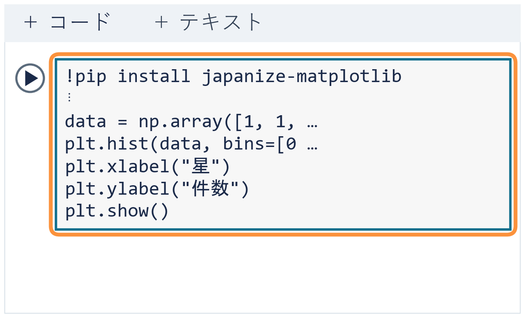

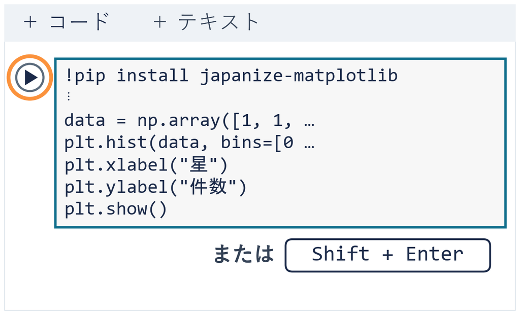

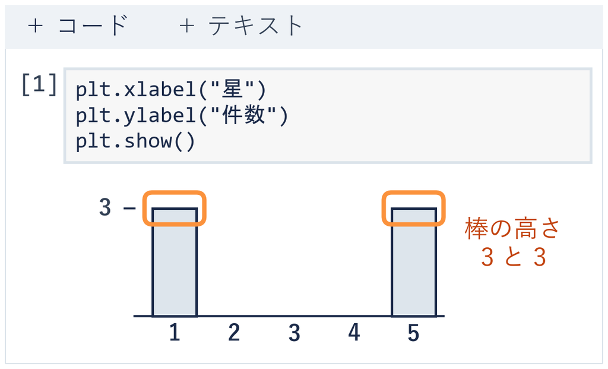

⏸ PAUSE 動画を止めて $3$ 分。図が出たら再生に戻る

## 100 件への 1 か所の変更

```python
!pip install japanize-matplotlib
import japanize_matplotlib
import numpy as np
import matplotlib.pyplot as plt
data = np.random.default_rng(0).choice([1, 5], size=100)
plt.hist(data, bins=[0.5, 1.5, 2.5, 3.5, 4.5, 5.5])
plt.xlabel("星")
plt.ylabel("件数")
plt.show()
```

| 行 | 部品 | 前の写経から変えた部品 |
| --- | --- | --- |
| 5 | **② データ** | `choice([1, 5], size=100)`＝1 か 5 を 100 回選ぶ |

※ 6〜9 行目は変えない。`default_rng(0)` の 0＝毎回同じ 100 件にする番号  
※ でたらめに選ぶので、ちょうど 50 件ずつにならない（この 100 件は 44 件と 56 件）

⏸ PAUSE 動画を止めて $2$ 分。図が出たら再生に戻る

## 演習 1-1 星 1 から星 3 への変更

演習 1-1

割れる店の星 1 を 1 件だけ星 3 に。どの棒が変わるか

```python
data = np.array([1, 1, 1, 5, 5, 5])
```

1. **先に考える**：変わる棒は ⓐ 星 1 だけ ⓑ 星 1 と星 3 ⓒ 全部
2. **新しいセルで変える**：写経を写して、  
   角かっこの中を `[1, 1, 3, 5, 5, 5]` に
3. **終わり**：図が出て、棒の高さが読めたら

⏸ PAUSE 動画を止めて $3$ 分。図が出たら再生に戻る

## 演習 1-1 の答え

答えは ⓑ。前と後のヒストグラムを並べる

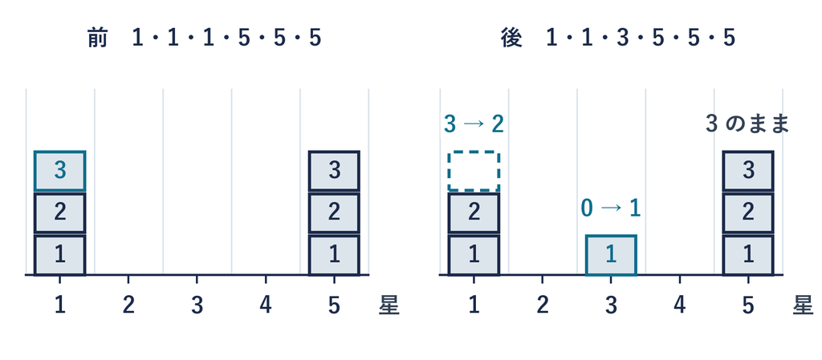

1 件が星 1 の区間から星 3 の区間へ移るだけ。合計は 6 件のまま

## 評価のぶれの大きさ

揃う店

6 件とも星 3  
棒は 1 本

割れる店

星 1 が 3 件、星 5 が 3 件  
棒は 2 本

問い：平均はどちらも 3.0。ぶれの大きさを 1 つの数で言えるか

定義と手順を見てから、5 件の小さな店で 1 段ずつ追う

## 標準偏差の定義

定義

**偏差**＝星から平均を引いた数

**分散**＝偏差の 2 乗の合計を、件数で割った数

**標準偏差**＝分散のルート

標準偏差は、平均からのふつうのずれ。全員が同じ星なら 0

## 標準偏差の求め方

手順

STEP 1平均を出す（星の合計を件数で割る）

STEP 2偏差を出す（星から平均を引く）

STEP 3偏差を 2 乗して、合計する

STEP 4合計を件数で割って分散、そのルートをとる

この授業では、STEP 1 も STEP 4 も件数で割る

## STEP 1・2 平均と偏差

[figure not shown]

**平均からのずれが偏差。平均より小さい星はマイナス**

## ✋ たしかめ 偏差の平均

たしかめ

偏差 −2・−1・0・＋1・＋2 をそのまま平均すると、いくつか

1. 予想を 1 つ選ぶ — ⓐ 0 ⓑ 1.2 ⓒ 2
2. プラスとマイナスの偏差を足すと、どうなるかで考える

⏸ PAUSE 動画を止めて $1$ 分。予想を決めたら再生に戻る

## STEP 3 偏差の 2 乗と合計

[figure not shown]

**2 乗すると、マイナスの偏差もプラスになる**

## STEP 4 件数で割ってルート

分散 ＝ 2 乗の合計 ÷ 件数 標準偏差 ＝ √分散

[figure not shown]

今回は 1 辺の 1.41 が、5 件の店の標準偏差

## 割れる店の 100 件の表

今度は、ヒストグラムで見た**割れる店の 100 件**で測る

| 件目 | 星 | 偏差 | 2 乗 |
| --- | --- | --- | --- |
| 1 | 5 | ＋1.76 | 3.10 |
| 2 | 5 | ＋1.76 | 3.10 |
| 3 | 5 | ＋1.76 | 3.10 |
| 4 | 1 | −2.24 | 5.02 |
| ⋮ | ⋮ | ⋮ | ⋮ |
| 平均 | 3.24 | 0 | 3.94 |

平均 ＝ 星の合計 ÷ 件数（星 1 が 44 件、星 5 が 56 件）  
今回は (1 × 44 ＋ 5 × 56) ÷ 100 ＝ 324 ÷ 100 ＝ 3.24

## 100 件の標準偏差

[figure not shown]

STEP 4 分散 ＝ (5.0176 × 44 ＋ 3.0976 × 56) ÷ 100 ＝ 3.9424

標準偏差 ＝ √3.9424 ≈ 1.99（5 件のときと同じ順）

## 写経 1 の前半の部品

```python
import numpy as np
data = np.array([1, 2, 3, 4, 5])
dev = data - data.mean()
sq = dev ** 2
var = sq.mean()
sd = np.sqrt(var)
print("平均", data.mean(), "分散", round(var, 2), "標準偏差", round(sd, 2))
```

| 行 | 部品 | 渡すもの | 返ってくるもの |
| --- | --- | --- | --- |
| 1 | **⓪ 準備** | numpy を `np` の名前で | 計算の道具が使える |
| 2 | **① データ** | 5 件の星を `[ ]` に並べる | 5 個の並び `data` |
| 3 | **② 偏差** | `data` から平均を引く | 5 個の偏差 `dev` |
| 4 | **③ 2 乗** | `dev` を `** 2` で 2 乗 | 5 個の 2 乗 `sq` |

## 写経 1 の後半の部品

```python
import numpy as np
data = np.array([1, 2, 3, 4, 5])
dev = data - data.mean()
sq = dev ** 2
var = sq.mean()
sd = np.sqrt(var)
print("平均", data.mean(), "分散", round(var, 2), "標準偏差", round(sd, 2))
```

| 行 | 部品 | 渡すもの | 返ってくるもの |
| --- | --- | --- | --- |
| 5 | **④ 平均** | `sq` に `.mean()` | 分散 `var`（2.0） |
| 6 | **⑤ ルート** | `np.sqrt` に `var` | 標準偏差 `sd`（1.41） |
| 7 | **⑥ 表示** | 名前と数を `print` に | セルの下に 1 行 |

※ `round(x, 2)`＝小数第 2 位までに丸める  
※ `"` は半角。全角の `”` だとエラー

## コードセルの写経と実行

1. **＋ コード**で空の  
   セルを足す
2. 写経 1 の 7 行を上  
   から写す
3. **▶** か **Shift + Enter** で実行  
   （Mac は Shift + return）
4. セルの下の 1 行で、  
   最後の数を見る

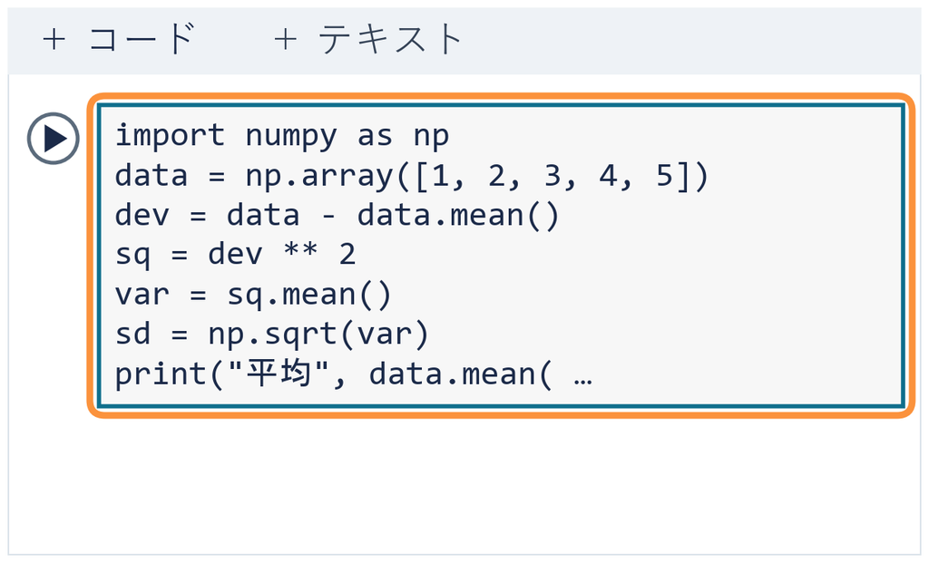

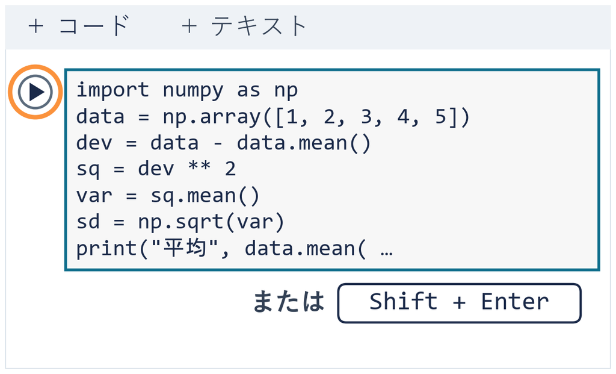

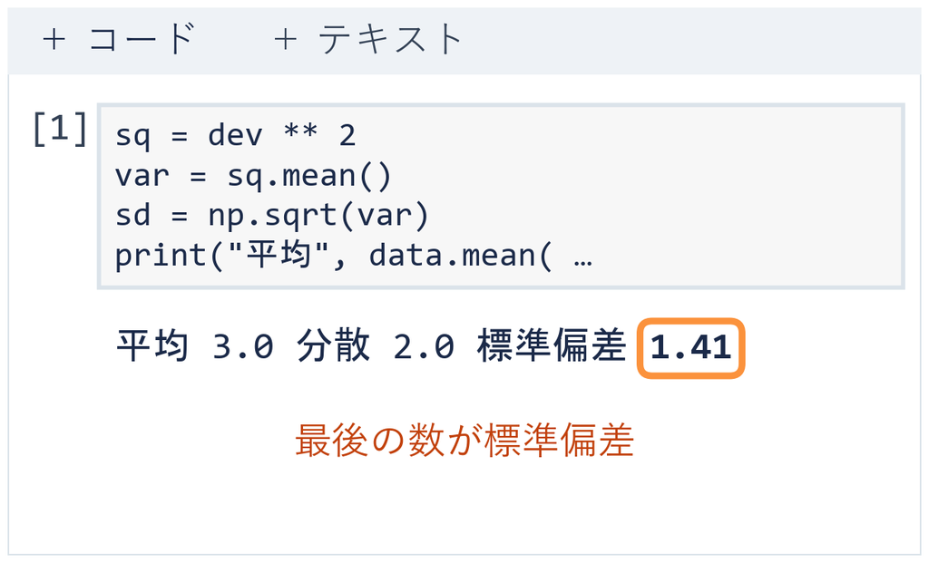

⏸ PAUSE 動画を止めて $3$ 分。1 行が出たら再生に戻る

## 写経 2 の 1 か所の変更

```python
import numpy as np
data = np.random.default_rng(0).choice([1, 5], size=100)
dev = data - data.mean()
sq = dev ** 2
var = sq.mean()
sd = np.sqrt(var)
print("平均", data.mean(), "分散", round(var, 2), "標準偏差", round(sd, 2))
```

| 行 | 部品 | 写経 1 から変えた部品 |
| --- | --- | --- |
| 2 | **① データ** | `choice([1, 5], size=100)`＝1 か 5 を 100 回選ぶ |
| 3-7 | **② 〜 ⑥** | 変えない（写経 1 とまったく同じ） |

※ `default_rng(0)` の 0＝毎回同じ 100 件にする番号

⏸ PAUSE 動画を止めて $2$ 分。1 行が出たら再生に戻る

## 2 つの写経に共通の形

[figure not shown]

決まった部品を上から順にはめるパズル。変えるのはデータの部品だけ

## 演習 1-2 ずれの小さい店

演習 1-2

星が 2・3・3・3・4 の店。標準偏差は 1.41 より大きいか

```python
data = np.array([1, 2, 3, 4, 5])
```

1. **先に考える**：ⓐ 大きい ⓑ 同じ ⓒ 小さい。  
   平均からのずれで予想する
2. **新しいセルで変える**：写経 1 を写して、  
   角かっこの中を `[2, 3, 3, 3, 4]` に
3. **終わり**：`標準偏差` の数が出たら

⏸ PAUSE 動画を止めて $3$ 分。1 行が出たら再生に戻る

## 演習 1-2 の答え

答えは ⓒ 小さい。5 件の店（星 1〜5）と、部品を 1 つずつ比べる

平均

$3$

$\to 3$

星の合計 15 も、件数 5 も同じ

偏差

$\text{−2〜＋2}$

$\to \text{−1〜＋1}$

1 と 5 が、2 と 4 に近づいた

2 乗の合計

$10$

$\to 2$

4 の正方形は 1 に、1 の正方形は 0 に

分散

$2$

$\to 0.4$

同じ 5 件で割る

標準偏差

$1.41$

$\to 0.63$

ルートをとる

平均が同じでも、ずれが小さいほど標準偏差は小さい

## まとめ

- 偏差＝星から平均を引いた数。そのまま平均すると 0
- 標準偏差＝偏差を 2 乗して合計し、件数で割って、ルートをとった数
- 最初の 2 つの店の標準偏差は、揃う店が 0、割れる店が 2
- 5 件の店は 1.41、割れる店の 100 件は 1.99
- コードは 7 つの部品のパズル。変えるのはデータの部品だけ
- 近道は `np.std(data)`（② 〜 ⑤ を 1 行に）

通販の星の内訳を見るとき、平均の横に「ぶれ」も読める

経済プログラミング特論II

第2回 — Topic02

標本平均の標準誤差

集め直すと、平均はどれだけ動くか

## 今日の道のり

1

中身を見る

演習 1-1・1-2

ヒストグラムとずれ

2

揺れを測る

演習 2-1・2-2

件数と標準誤差

3

消えない揺れ

演習 3-1

ショックを0に

4

条件を添える

演習 4-1・4-2

seed と一文

見えている平均は、読んだ件数しだいで揺れる

## ✋ たしかめ 3 件の平均

割れる店（星 1 と星 5 が半々）は、行った人全員に聞けば平均 3

たしかめ

レビューを 3 件だけ読む。3 件の平均は 3 になるか

1. 予想を選ぶ — ⓐ いつも 3 ⓑ ときどき 3 ⓒ 一度もならない
2. 3 件の合計がいくつなら平均 3 か、で考える

⏸ PAUSE 動画を止めて $1$ 分。予想を決めたら再生に戻る

## 母集団と標本の定義

定義

**母集団**＝知りたい相手の全員（店に行った全員）

**標本**＝母集団から実際に読めた N 件

**標本平均**＝標本 N 件の平均。いま見えている星

**モンテカルロ法**＝計算機で標本を何度も作り直して調べる方法

割れる店の母集団の平均は 3。標本平均は、読めた N 件しだいで変わる

## 標本平均の揺れの調べ方

手順

STEP 1母集団から N 件を読む（標本）

STEP 2その N 件の平均を出す（標本平均）

STEP 3読み直して、標本平均をヒストグラムに積む

読み方を全部数えられるなら全部、数えきれないならモンテカルロ法で

## STEP 1〜3 3 件の読み方 8 通り

[figure not shown]

**答えは ⓒ。合計は 3・7・11・15 だけで、平均 3 に要る 9 にならない**

## デモ：平均の揺れを見る

数の話

割れる店のレビューを、N件ずつ何度も読み直す

- **何を見るか**：件数を増やすと、左右どちらの広がりが縮むか。  
  読むのは「平均の揺れ」の数
- **図の意味**：左＝N件の星の件数／右＝平均を積み上げた図
- **操作**：止めて3分。manaba の lecture02_means_demo.  
  html をブラウザで開き、タブを押す

ミッション 件数を増やすと、左右どちらの広がりが縮むか

※ 次のスライドへ進むときは、デモの枠の外を一度クリックしてから ← → キーを押す

[interactive chart not shown]

## 100 件の標本平均のヒストグラム

今度は **100 件**。読み方は数えきれないので、計算機で 1000 回読み直す

[figure not shown]

**縮むのは標本平均のヒストグラム。1 件ずつの星は 1 と 5 のまま**

## 標本平均の写経の前半

```python
import numpy as np
import matplotlib.pyplot as plt
N = 3
rng = np.random.default_rng(0)
means = rng.choice([1, 5], size=(1000, N)).mean(axis=1)
print("平均の標準偏差", round(means.std(), 2))
plt.hist(means, bins=21, range=(0.9, 5.1))
plt.xlabel("N 件の平均")
plt.ylabel("回数")
plt.show()
```

| 行 | 部品 | 渡すもの | 返ってくるもの |
| --- | --- | --- | --- |
| 1-2 | **⓪ 準備** | `np`・`plt` の名前 | 計算と図の道具 |
| 3 | **① 件数** | 1 回に読む件数 | `N` は 3 |
| 4 | **② 乱数** | 番号 `0` | 同じ乱数の道具 `rng` |
| 5 | **③ 読み直す** | 1000 行 × N 列の星 | 行ごとの平均 1000 個 |

## 標本平均の写経の後半

```python
import numpy as np
import matplotlib.pyplot as plt
N = 3
rng = np.random.default_rng(0)
means = rng.choice([1, 5], size=(1000, N)).mean(axis=1)
print("平均の標準偏差", round(means.std(), 2))
plt.hist(means, bins=21, range=(0.9, 5.1))
plt.xlabel("N 件の平均")
plt.ylabel("回数")
plt.show()
```

| 行 | 部品 | 渡すもの | 返ってくるもの |
| --- | --- | --- | --- |
| 6 | **④ 揺れ** | `means.std()` | 標本平均の標準偏差 |
| 7 | **⑤ 棒を積む** | 幅 0.2 の区間 21 個 | ヒストグラム |
| 8-9 | **⑥ 軸の名前** | 横と縦の名前 | 軸に名前が付く |
| 10 | **⑦ 表示** | 何も渡さない | セルの下に図 |

## 標本平均の写経と実行

1. **＋ コード**で空の  
   セルを足す
2. 写経の 10 行を上  
   から写す
3. **▶** か **Shift + Enter** で実行  
   （Mac は Shift + return）
4. 棒が 4 本で、  
   3 に棒が無いことを見る

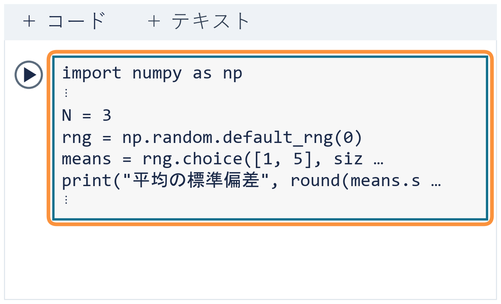

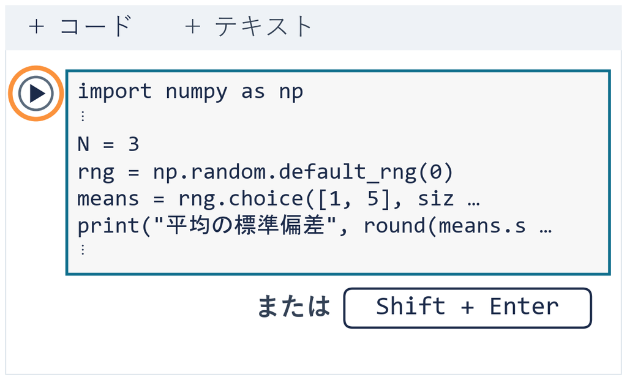

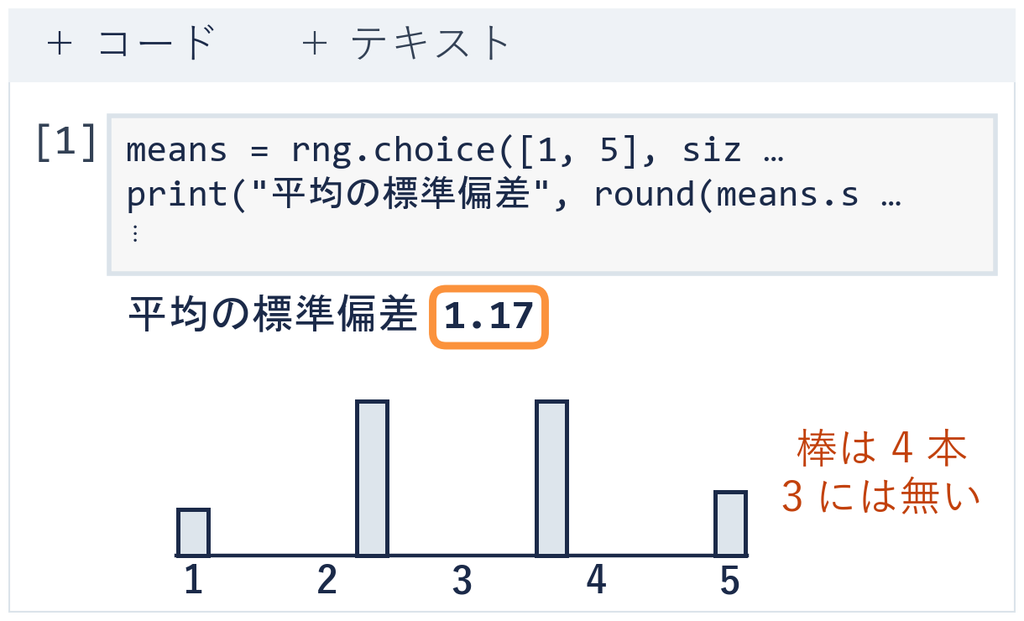

⏸ PAUSE 動画を止めて $3$ 分。図が出たら再生に戻る

## 100 件への 1 か所の変更

```python
import numpy as np
import matplotlib.pyplot as plt
N = 100
rng = np.random.default_rng(0)
means = rng.choice([1, 5], size=(1000, N)).mean(axis=1)
print("平均の標準偏差", round(means.std(), 2))
plt.hist(means, bins=21, range=(0.9, 5.1))
plt.xlabel("N 件の平均")
plt.ylabel("回数")
plt.show()
```

| 行 | 部品 | 前の写経から変えた部品 |
| --- | --- | --- |
| 3 | **① 件数** | `N = 100`＝1 回に読む件数を 100 件に |

※ 4〜10 行目は変えない。1 回目の 100 件は、ヒストグラムで見た 100 件と同じ

⏸ PAUSE 動画を止めて $2$ 分。図が出たら再生に戻る

## 演習 2-1 件数を減らした揺れ

演習 2-1

N を 100 から 25 に。標本平均の標準偏差は 0.2 より大きいか

```python
N = 100
```

1. **先に考える**：ⓐ 大きい ⓑ 同じ ⓒ 小さい。1 回に読む件数で
2. **新しいセルで変える**：写経を写して、3 行目を `N = 25` に
3. **終わり**：`平均の標準偏差` の数と図が出たら

⏸ PAUSE 動画を止めて $3$ 分。数が出たら再生に戻る

## 演習 2-1 の答え

答えは ⓐ 大きい。100 件のときと、部品を 1 つずつ比べる

件数

$100$

$\to 25$

1 回に読む件数  
が 4 分の 1

1 件ずつの星

$\text{1 と 5}$

$\to \text{1 と 5}$

星の出方は変わらない

平均の最小〜最大

$\text{2.4〜3.56}$

$\to \text{1.64〜4.52}$

打ち消し合いにくい

平均の標準偏差

$0.2$

$\to 0.39$

0.2 より大きい

件数を 4 分の 1 にすると、揺れはおよそ 2 倍

## 標準誤差の定義と求め方

問い：件数を何倍にすると、標本平均の揺れは半分になるか

定義

**標準誤差**＝標本平均の標準偏差（読み直したときの揺れ）

**式**＝1 件ずつの標準偏差 ÷ √件数

手順

STEP 11 件ずつの星の標準偏差を出す

STEP 2件数のルートを出す

STEP 3STEP 1 の数を STEP 2 の数で割る

条件：1 件ずつの星が、ほかの件と関係なく決まること

## STEP 1〜3 件数 1・4・16 の標準誤差

今回は割れる店。全員に聞いたときの 1 件ずつの標準偏差は 2

[figure not shown]

**件数が 4 倍になるたびに、標準誤差は半分**

※ 2 ＝ √4（偏差 ±2・2 乗 4）。3 件の 8 通りを全部数えると、平均の標準偏差は 2 ÷ √3 ≈ 1.15

## 計算機の揺れと式の標準誤差

今度は、計算機で 1000 回読み直した揺れ（写経と演習 2-1）を式と並べる

| 件数 N | 計算機（1000 回） | 式 2 ÷ √N |
| --- | --- | --- |
| 25 | 0.39 | 2 ÷ 5 ＝ 0.4 |
| 100 | 0.2 | 2 ÷ 10 ＝ 0.2 |

レビュー 25 件の店の平均は、100 件の店の約 2 倍揺れる

## 標準誤差の写経

```python
for n in (25, 100):
    rng = np.random.default_rng(0)
    means = rng.choice([1, 5], size=(1000, n)).mean(axis=1)
    print(n, "件", round(means.std(), 2), "式", round(2 / np.sqrt(n), 2))
```

| 行 | 部品 | 渡すもの | 返ってくるもの |
| --- | --- | --- | --- |
| 1 | **① 件数を順に** | `(25, 100)` | `n` が 25、次に 100 |
| 2-3 | **② 読み直す** | 前の写経と同じ形 | 標本平均 1000 個 |
| 4 | **③ 並べる** | 計算機の揺れと式 | 1 行に 2 つの数 |

※ 2〜3 行目は前の写経の `N` を `n` にした形・2〜4 行目は半角の空白 4 つで字下げ

## 標準誤差の写経と実行

1. **＋ コード**で空の  
   セルを足す
2. 写経の 4 行を写す  
   （2〜4 行目は字下げ）
3. **▶** か **Shift + Enter** で実行  
   （Mac は Shift + return）
4. 出た 2 行で、計算機と式  
   の数を見比べる

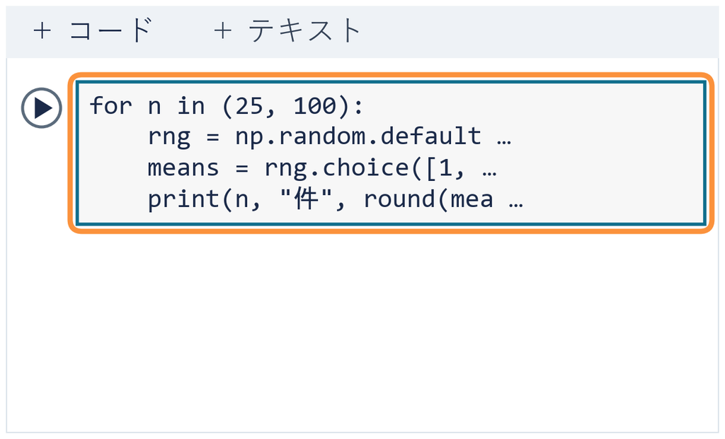

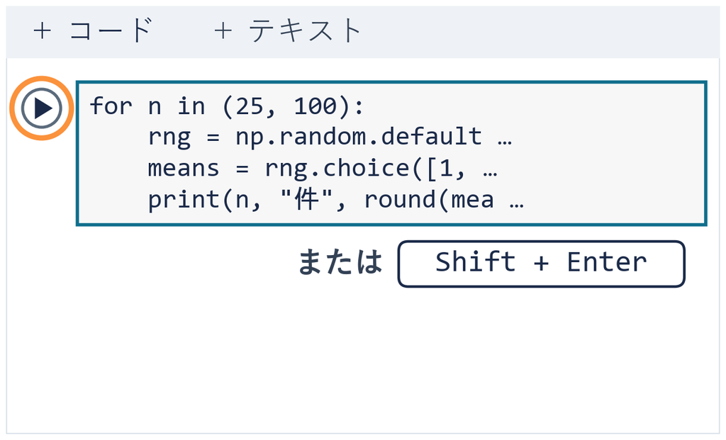

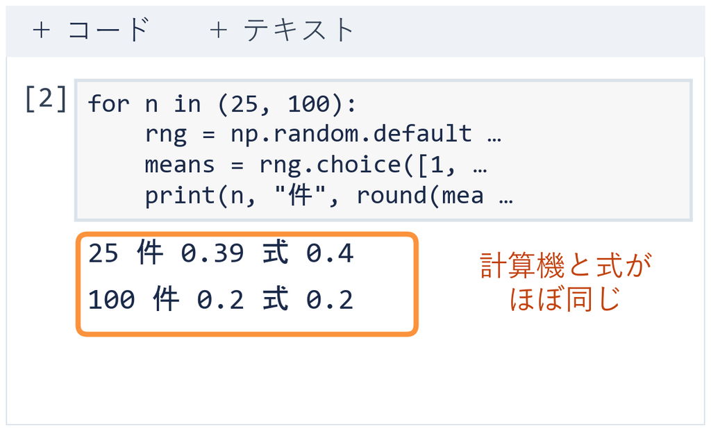

⏸ PAUSE 動画を止めて $2$ 分。2 行が出たら再生に戻る

## 演習 2-2 標準誤差 0.25 の件数

演習 2-2

標準誤差を 0.25 にするには、何件いるか

```python
for n in (25, 100):
    rng = np.random.default_rng(0)
    means = rng.choice([1, 5], size=(1000, n)).mean(axis=1)
    print(n, "件", round(means.std(), 2), "式", round(2 / np.sqrt(n), 2))
```

1. **先に考える**：ⓐ 32 件 ⓑ 64 件 ⓒ 256 件（16 件で 0.5）
2. **新しいセルで変える**：写経を写して、1 行目の `100` を選んだ件数に
3. **終わり**：式の数が 0.25 になったら

⏸ PAUSE 動画を止めて $3$ 分。0.25 が出たら再生に戻る

## 演習 2-2 の答え

答えは ⓑ 64 件。式に 0.25 を入れて、1 段ずつ戻す

目標

$2 \div \sqrt{N}$

$= 0.25$

式に、ほしい揺れを入れる

ルート

$\sqrt{N}$

$= 2 \div 0.25 = 8$

割る数と答えを入れかえる

件数

$N$

$= 8 \times 8 = 64$

ルートが 8 になる数

計算機

$\text{64 件}$

$\to 0.25$

演習のセルの出力

16 件の 0.5 を半分の 0.25 にするには、4 倍の 64 件

## まとめ

- 標本平均は、読み直すたびに揺れる。3 件では平均 3 にならない
- 揺れは、読み直した標本平均のヒストグラムで見る
- 縮むのは標本平均のヒストグラム。1 件ずつの星は 1 と 5 のまま
- 標準誤差 ＝ 1 件ずつの標準偏差 ÷ √件数。件数 4 倍で半分
- コードは前の写経と同じ形。変えるのは件数の部品だけ

ただし、この式には条件がある

経済プログラミング特論II

第2回 — Topic03

共通ショック

人数を増やしても消えない揺れ

## 今日の道のり

1

中身を見る

演習 1-1・1-2

ヒストグラムとずれ

2

揺れを測る

演習 2-1・2-2

件数と標準誤差

3

消えない揺れ

演習 3-1

ショックを0に

4

条件を添える

演習 4-1・4-2

seed と一文

人数を増やしても消えない揺れがある

## レビュー1000件の平均

開店日に SNS で話題が広がり  
同じ投稿を見た人がまとめてレビューを書いた

問い：レビューが 1000 件あれば、この店の平均の評価は確かと言えるか

- **①** はい。1000 件あれば、平均はほぼ動かない
- **②** いいえ。1000 件でも、平均の揺れはほとんど減らない
- **③** いいえ。件数が多いほど、平均は大きく動く

⏸ PAUSE 動画を止めて $1$ 分。①〜③から予想を 1 つ選んだら再生に戻る

## 共通ショックの定義

定義

**個人の雑音**＝1 人ずつばらばらに加わるずれ

**共通ショック**＝集団の全員に、同じだけ加わるずれ

**満足度**＝50 ＋ 共通ショック ＋ 個人の雑音

**独立**＝1 人のずれが、ほかの人のずれと無関係なこと

星は 1〜5 しかなく、ずれを足しにくい  
ここからは 50 を中心にした人工の満足度で考える

## 平均のずれの分け方

手順

STEP 150 からのずれを、共通ショックと雑音に分ける

STEP 2雑音を平均する

STEP 3共通ショックを平均する

STEP 42 つを足す。これが、平均の 50 からのずれ

割る数は、STEP 2 も STEP 3 も、いつも人数

## STEP 1・2 雑音だけの 3 人

まずは、共通ショックの無い 3 人。満足度は 45・50・55

[figure not shown]

**雑音はプラスとマイナスが打ち消し合い、平均は 50 のまま**

## STEP 3・4 全員に同じ ＋5

同じ 3 人の全員に、共通ショック ＋5 が加わる

[figure not shown]

**全員に同じだけ加わると、打ち消す相手がいない。平均も同じだけ動く**

## STEP 1〜4 最初の集団の 100 人

今度は、計算機で作った **1000 集団のうち、最初の集団（100 人）**

[figure not shown]

3 人のときと同じ順。雑音はほぼ打ち消し合い、  
共通ショックはそのまま残る

## 1000 集団の平均のヒストグラム

共通ショックは集団ごとに違う（標準偏差 5）。  
1000 集団の平均の標準偏差を「揺れ」と呼ぶ

[figure not shown]

**人数を 10 倍にして細くなるのは、共通ショックなしだけ**

## 人数を 10 倍にしたときの揺れ

100 人 → 1000 人で、部品を 1 つずつ比べる

なしの揺れ

$1.04$

$\to 0.32$

雑音は独立で打ち消し合い  
1 ÷ √10 ≈ 1 ÷ 3.16 に縮む

共通ショック

$5$

$\to 5$

集団に 1 つ。人数に関係なく、標準偏差 5 のまま

ありの揺れ

$5.0$

$\to 5.12$

共通ショックの 5 が残り、5 のまわりで止まる

入口の問いの答えは ②。同じ投稿に引っ張られたずれは、  
件数を増やしても消えない

## 共通ショックの写経の前半

```python
import numpy as np
noise = np.array([-5, 0, 5])
shock = 5
nashi = 50 + noise
ari = 50 + shock + noise
print("なし", nashi, "平均", nashi.mean())
print("あり", ari, "平均", ari.mean())
```

| 行 | 部品 | 渡すもの | 返ってくるもの |
| --- | --- | --- | --- |
| 1 | **⓪ 準備** | numpy を `np` の名前で | 計算の道具が使える |
| 2 | **① 雑音** | 3 人の雑音を `[ ]` に並べる | 3 個の並び `noise` |
| 3 | **② 共通** | 全員に足す 5 | 1 つの数 `shock` |
| 4 | **③ なし** | 50 に `noise` を足す | 3 人の満足度 `nashi` |

## 共通ショックの写経の後半

```python
import numpy as np
noise = np.array([-5, 0, 5])
shock = 5
nashi = 50 + noise
ari = 50 + shock + noise
print("なし", nashi, "平均", nashi.mean())
print("あり", ari, "平均", ari.mean())
```

| 行 | 部品 | 渡すもの | 返ってくるもの |
| --- | --- | --- | --- |
| 5 | **④ あり** | 50 に 2 つを足す | 3 人の満足度 `ari` |
| 6-7 | **⑤ 表示** | 名前と数を `print` に | セルの下に 2 行 |

※ `50 + noise` は、3 人のそれぞれに 50 を足す  
※ `nashi`＝なし、`ari`＝あり。`"` は半角（全角の `”` だとエラー）

## 共通ショックの写経と実行

1. **＋ コード**で空の  
   セルを足す
2. 写経の 7 行を上から写す
3. **▶** か **Shift + Enter** で実行  
   （Mac は Shift + return）
4. セルの下の 2 行で、  
   最後の数を見る

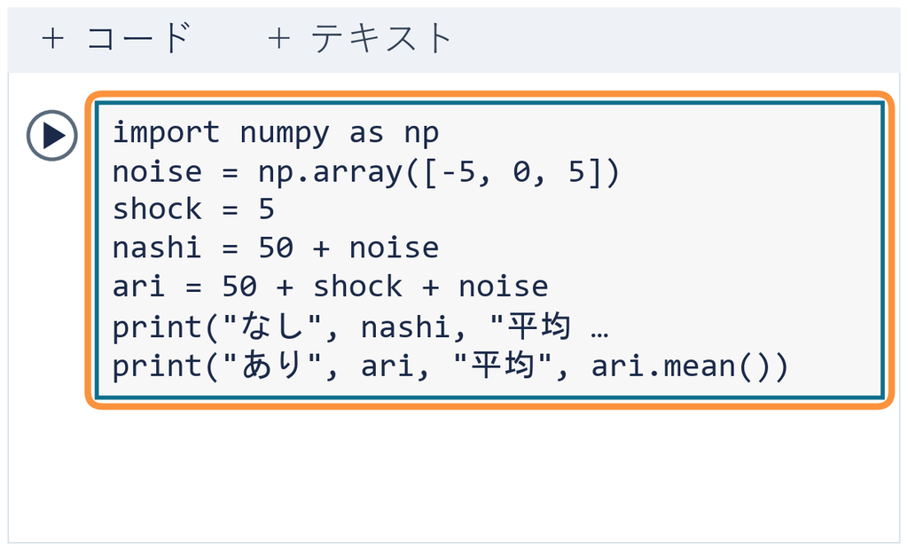

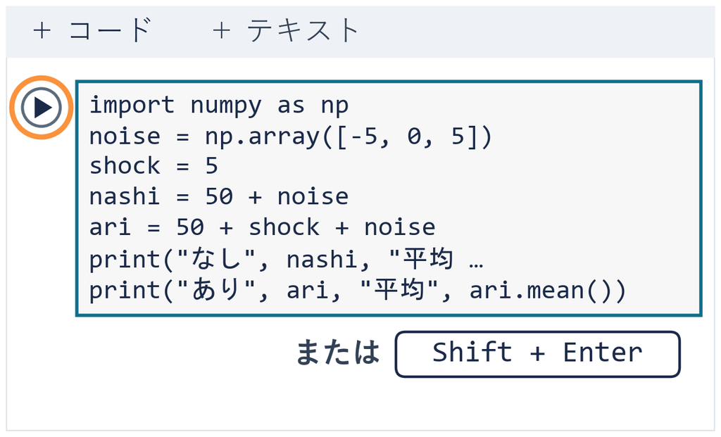

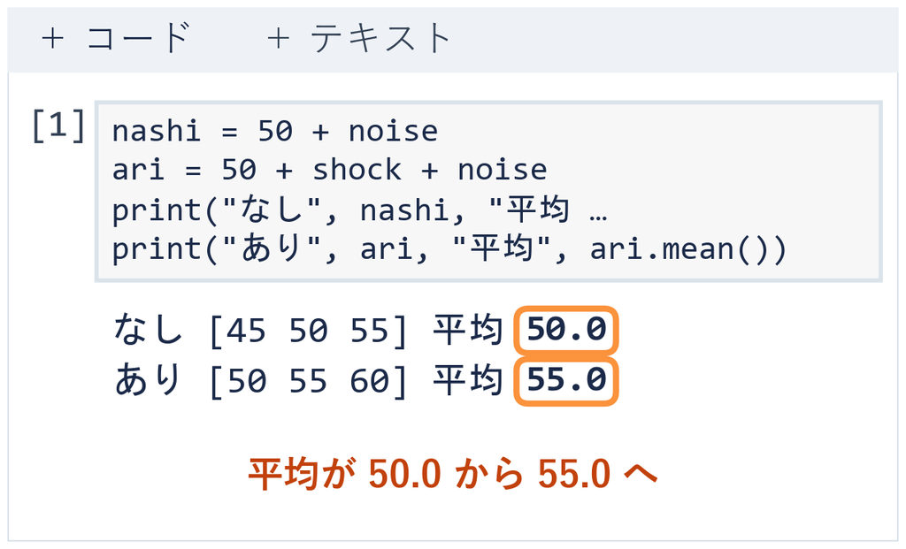

⏸ PAUSE 動画を止めて $3$ 分。2 行が出たら再生に戻る

## 1000 集団への変更の前半

```python
import numpy as np
rng = np.random.default_rng(0)
for n in (100, 1000):
    noise = rng.normal(0, 10, size=(1000, n))
    shock = rng.normal(0, 5, size=(1000, 1))
    nashi = (50 + noise).mean(axis=1)
    ari = (50 + shock + noise).mean(axis=1)
    print(n, "人 なし", round(nashi.std(), 2), "あり", round(ari.std(), 2))
```

| 行 | 部品 | 写経 1 から変えたところ |
| --- | --- | --- |
| 2 | **くじ** | `rng`＝乱数を出す道具（0＝毎回同じ数にする番号） |
| 3 | **人数** | 4〜8 行目を、100 人と 1000 人で 2 回くり返す |
| 4 | **① 雑音** | `rng.normal(0, 10, …)` ＝0 のまわりに散る数（標準偏差 10） |
| 5 | **② 共通** | `size=(1000, 1)`＝集団に 1 つ。 その集団の全員に同じ値 |

## 1000 集団への変更の後半

```python
import numpy as np
rng = np.random.default_rng(0)
for n in (100, 1000):
    noise = rng.normal(0, 10, size=(1000, n))
    shock = rng.normal(0, 5, size=(1000, 1))
    nashi = (50 + noise).mean(axis=1)
    ari = (50 + shock + noise).mean(axis=1)
    print(n, "人 なし", round(nashi.std(), 2), "あり", round(ari.std(), 2))
```

| 行 | 部品 | 写経 1 から変えたところ |
| --- | --- | --- |
| 6-7 | **③ なし ④ あり** | `.mean(axis=1)`＝集団ごとに n 人を平均（1000 個） |
| 8 | **⑤ 表示** | `.std()`＝1000 個の平均の標準偏差（揺れ） |

※ 4〜7 行目は写経 1 の 2〜5 行目と同じ並び。`size=(1000, n)`＝1000 集団 × n 人

⏸ PAUSE 動画を止めて $3$ 分。2 行が出たら再生に戻る

## 演習 3-1 共通ショックを 0 にした揺れ

演習 3-1

共通ショックを 0 にすると、1000 人の「あり」の揺れはいくつか

```python
shock = rng.normal(0, 5, size=(1000, 1))
```

1. **先に考える**：ⓐ 5 前後のまま ⓑ なしと同じ 0.32 前後 ⓒ 0
2. **新しいセルで変える**：写経 2 を写して、5 行目の `5` を `0` に
3. **終わり**：2 行が出て、1000 人の「あり」の数が読めたら

⏸ PAUSE 動画を止めて $3$ 分。2 行が出たら再生に戻る

## 演習 3-1 の答え

答えは ⓑ。1000 人の「あり」は 5.12 → 0.32。部品を 1 つずつ追う

共通ショック

$5$

$\to 0$

2 つ目の数 5 を 0 に

足す値

$\text{ばらばら}$

$\to 0$

どの集団の全員にも 0

あり

$\text{なし＋共通}$

$\to \text{なし}$

50 ＋ 雑音だけになる

ありの揺れ

$5.12$

$\to 0.32$

なしの 0.32 と同じ

人数で消えなかった揺れは、共通ショックから来ていた

## まとめ

- 個人の雑音：1 人ずつばらばら。独立なので、平均では打ち消し合う
- 共通ショック：全員に同じだけ。  
  平均にそのまま乗る（3 人で 50 → 55）
- 人数 10 倍で、なしの揺れは 1.04 → 0.32。ありは 5 のまわりで止まる
- 写経 2 は写経 1 と同じ部品の並び。  
  変えたのは数の作り方と、集団ごとの平均

「回答 1 万人」の調査を見たら、件数より、  
全員が同じ話題に引っ張られていないかを見る

経済プログラミング特論II

第2回 — Topic04

再現性と結論の範囲

1回の差を、条件つきの一文にする

## 今日の道のり

1

中身を見る

演習 1-1・1-2

ヒストグラムとずれ

2

揺れを測る

演習 2-1・2-2

件数と標準誤差

3

消えない揺れ

演習 3-1

ショックを0に

4

条件を添える

演習 4-1・4-2

seed と一文

問い：割れる店（本当の平均 3）のレビューを、計算機で 5 件だけ読む  
もう一度読むと同じ 5 件か。平均は 3.0 より上か下か

## seed の定義

定義

**乱数**＝計算機が作る、でたらめに見える数の並び

**seed**＝乱数の出発点の番号

**再現**＝同じ seed で、同じ並びをもう一度出すこと

トピック1 から書いてきた `default_rng(0)` の 0 が seed。  
同じ番号なら、誰が実行しても同じ並び

## seed での確かめ方

手順

STEP 1seed を決める（0 から順に）

STEP 2その seed で、割れる店の 5 件を選ぶ

STEP 35 件の平均を出す（合計 ÷ 5）

STEP 4揃う店の 3.0 と比べる（上か下か）

STEP 1 に戻って seed だけ変えると、別の集め直しになる

## STEP 1〜4 seed 0・1・2 の 5 件

[figure not shown]

**同じ seed なら同じ 5 件。seed を変えると、上にも下にもなる**

## 1000 回の集め直しの上下

今度は、5 件の集め直しを **1000 回**（トピック2 と同じ規模）

[figure not shown]

**1 回ごとの上下は入れ替わる。1000 回では、seed を変えてもほぼ半々**

## seed を回す写経

```python
import numpy as np
STARS = [1, 5]
for s in range(6):
    five = np.random.default_rng(s).choice(STARS, size=5)
    print("seed", s, "5件", five, "平均", five.mean())
```

| 行 | 部品 | 渡すもの | 返ってくるもの |
| --- | --- | --- | --- |
| 1-2 | **⓪ 準備** | numpy と `[1, 5]` | `np` と `STARS` が使える |
| 3 | **① seed を回す** | `range(6)` | `s` に 0〜5 を 1 つずつ |
| 4 | **② 5 件を選ぶ** | seed の `s` と `size=5` | その seed の 5 件 `five` |
| 5 | **③ 表示** | 平均 `five.mean()` も | seed・5 件・平均の行 |

※ 4・5 行目の頭は半角の空白 4 つ。for の中で、s ごとにくり返す行の印

## seed の写経と実行

1. **＋ コード**で空の  
   セルを足す
2. 写経の 5 行を上から写す
3. **▶** か **Shift + Enter** で実行  
   （Mac は Shift + return）
4. 1 行目の seed 0 で、  
   5 件と平均 3.4 を見る

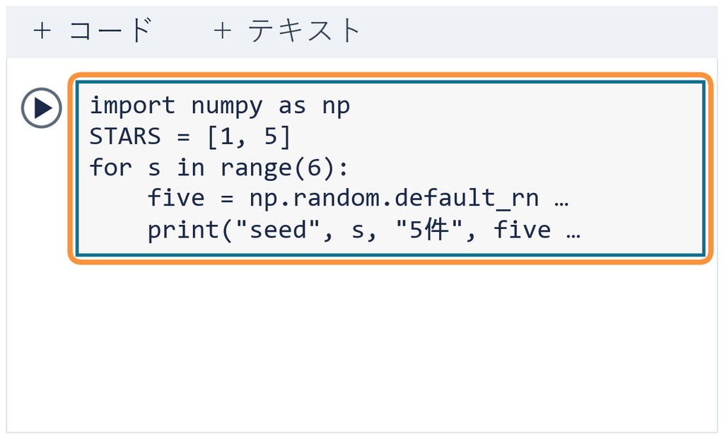

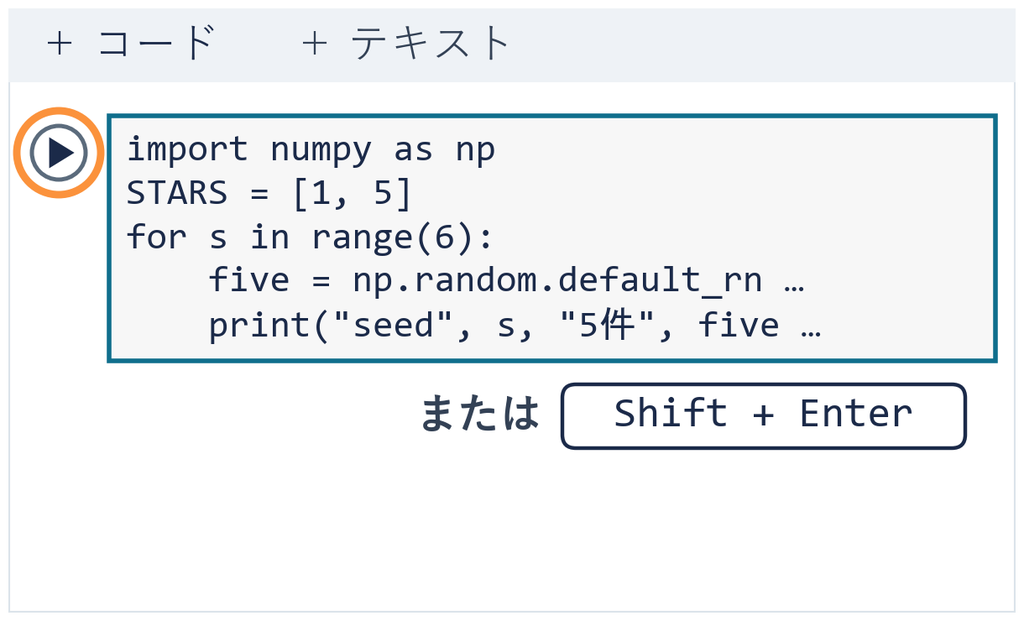

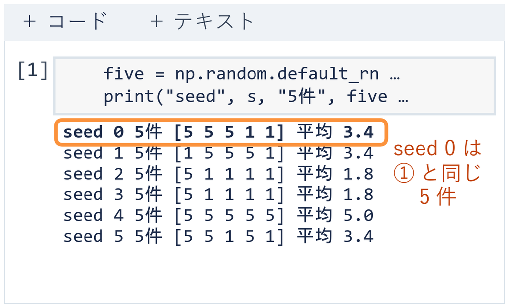

⏸ PAUSE 動画を止めて $3$ 分。6 行が出たら再生に戻る

## 1000 回への書き換え

```python
import numpy as np
STARS = [1, 5]
rng = np.random.default_rng(0)
means = rng.choice(STARS, size=(1000, 5)).mean(axis=1)
print("上", (means > 3).sum(), "下", (means < 3).sum())
```

| 行 | 部品 | 渡すもの | 返ってくるもの |
| --- | --- | --- | --- |
| 3 | **① seed を決める** | `default_rng(0)` | seed 0 の道具 `rng` |
| 4 | **② 1000 回選ぶ** | `size=(1000, 5)` | 1000 個の平均 `means` |
| 5 | **③ 上下を数える** | `means > 3` | `.sum()` で数えた個数 |

※ 4 行目はトピック2 の写経と同じ形。seed 1 にするのは 3 行目の 0 だけ

⏸ PAUSE 動画を止めて $2$ 分。上と下の回数が出たら再生に戻る

## 演習 4-1 10 個の seed

演習 4-1

range(6) を range(10) に。seed 0〜5 の 6 行はどうなるか

```python
for s in range(6):
    five = np.random.default_rng(s).choice(STARS, size=5)
    print("seed", s, "5件", five, "平均", five.mean())
```

1. **先に考える**：6 行は ⓐ 前と同じ ⓑ 全部変わる ⓒ 一部だけ変わる
2. **新しいセルで変える**：写経を写して、  
   for の行を `for s in range(10):` に
3. **終わり**：10 行の平均を記録表に写し、3.0 より上と下を数えたら

⏸ PAUSE 動画を止めて $3$ 分。上と下を数えたら再生に戻る

## 演習 4-1 の答え

答えは ⓐ 前と同じ。seed 0 の 1 行を、部品の順にたどる

**seed**0 のまま（range(10) も 0 から始まる）

**5 件**出発点が同じなので、5・5・5・1・1 のまま

**平均**3.4 のまま。seed 1〜5 も同じ理由で変わらない

| seed | 0 | 1 | 2 | 3 | 4 | 5 | **6** | **7** | **8** | **9** |
| --- | --- | --- | --- | --- | --- | --- | --- | --- | --- | --- |
| 平均 | 3.4 | 3.4 | 1.8 | 1.8 | 5.0 | 3.4 | **3.4** | **5.0** | **2.6** | **2.6** |
| 3.0 と | 上 | 上 | 下 | 下 | 上 | 上 | **上** | **上** | **下** | **下** |

増えたのは seed 6〜9 の 4 行。10 回で上 6 回・下 4 回

## 1 回の差の 3 つの言い方

seed 0 の 5 件は平均 3.4、seed 2 は 1.8。揃う店はいつも 3.0

ⓐ割れる店は、揃う店より評価が高い

ⓑ割れる店の 5 件の平均 3.4 は、揃う店の 3.0 より高い

ⓒseed 0 の 5 件は 3.4、seed 2 は 1.8。5 件の 1 回の差では上下は言えない

問い：どの文なら、そのまま人に伝えてよいか

| 文 | どう集めたか | 出た数 | 言えないこと |
| --- | --- | --- | --- |
| ⓐ | ✕ | ✕ | ✕ |
| ⓑ | △ 5 件だけ | ○ 3.4 と 3.0 | ✕ |
| ⓒ | ○ 5 件・seed | ○ 3.4 と 1.8 | ○ 上下 |

## 条件つきの一文の定義

定義

**条件**＝どう集めたか（何件・どの seed・何回）

**結果**＝出た数そのもの

**範囲**＝この結果からは言えないこと  
（言える範囲の外）

**条件つきの一文**＝条件・結果・範囲の 3 つを入れた文

前のページの ⓒ が、条件つきの一文  
ニュースの「◯人の調査で」も、この 3 つで読む

## 1000 回の結果の一文

今度は、seed 0 と seed 1 の 1000 回の集め直しを、同じ型に入れる

**条件**5 件の集め直しを 1000 回。seed 0 と seed 1 の 2 通り

**結果**3.0 より上は 502 回と 485 回、下は 498 回と 515 回

**範囲**上下は 1 回ごとに入れ替わる。評価が高いとは言えない

3 つを 1 文につなげば、そのまま人に渡せる

## 一文の型の写経と表示

1. **＋ テキスト**で文字の  
   セルを足す
2. 型の 3 行を写す（行頭は  
   半角の `-` と空白）
3. **Shift + Enter** で表示  
   （Mac は Shift + return）
4. 太字の 3 行が出たら、  
   「：」のあとに書く

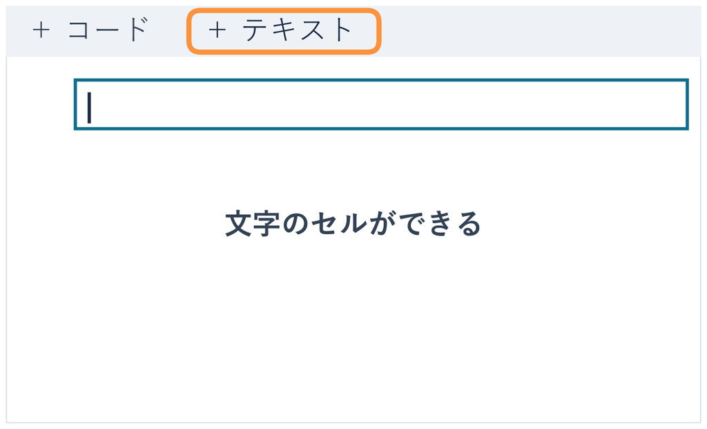

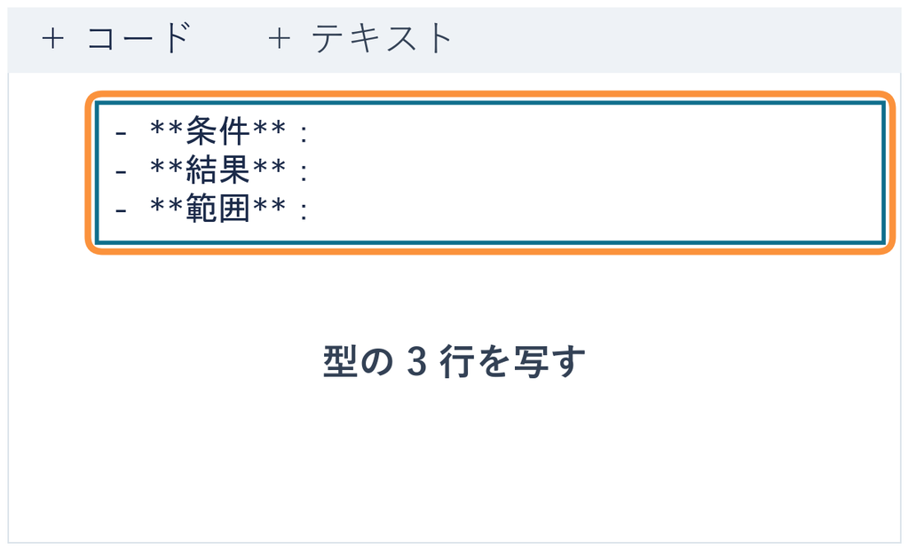

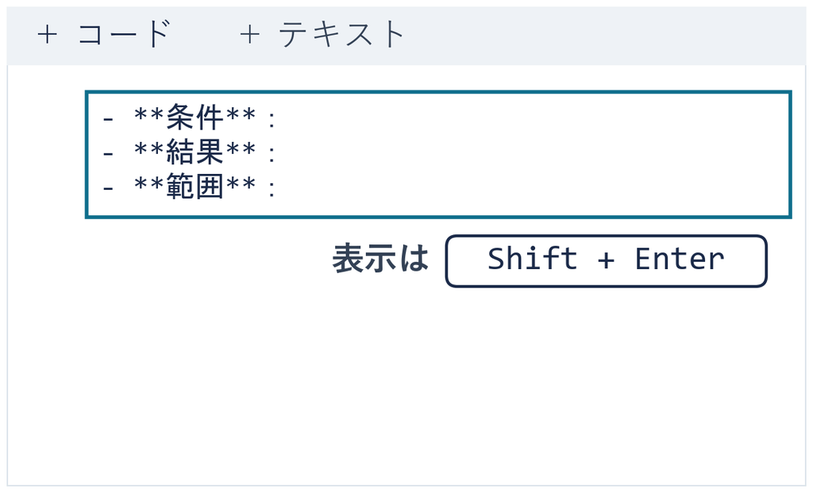

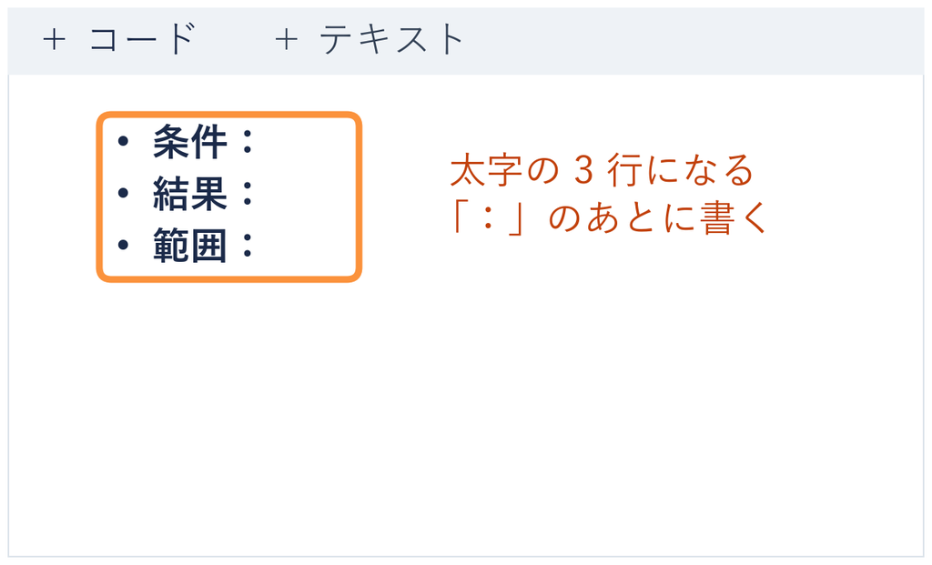

⏸ PAUSE 動画を止めて $2$ 分。太字の 3 行が出たら再生に戻る

## 演習 4-2 記録表からの一文

演習 4-2

演習 4-1 の記録表 10 行を、条件つきの一文にする

1. **先に考える**：10 回で上が 6 回。  
   割れる店の評価が高いと ⓐ 言える ⓑ 言えない
2. **書く**：型の 3 行の「：」のあとに、記録表の数を入れる
3. **終わり**：条件・結果・範囲の 3 行が埋まったら

⏸ PAUSE 動画を止めて $3$ 分。3 行が埋まったら再生に戻る

## 演習 4-2 の答えの例

答えは ⓑ 言えない。型に入れた例

**条件**割れる店の 5 件を読む。seed 0〜9 の 10 回

**結果**3.0 より上が 6 回、下が 4 回

**範囲**上下は seed で入れ替わる。この 10 回から、評価が高いとは言えない

6 対 4 は 10 回だけの片寄り。1000 回の集め直し（seed 0）では 502 対 498

※ 上下が半々でも、10 回で上が 6 回以上になる確率は約 0.377（よく起きる片寄り）

## 第2回 小課題の提出

STEP 1小課題ノート lecture02_mean_practice.ipynb を Colab で開く

STEP 2トピック1〜4 の写経と演習のセルを上から実行し  
一番下の提出前チェックで全部 `[ok]` にする

STEP 3最後に、演習 4-1 の記録表と演習 4-2 の一文を書く

STEP 4ファイル → ダウンロード → .ipynb で保存して出す

提出先は manaba の「第2回 小課題」（締切も manaba に表示）  
開けないときは、記録表と一文だけでも出す

## まとめ

- seed＝乱数の出発点の番号。同じ seed なら同じ並び（再現）
- seed を変える＝別の集め直し。1 回の差の上下は入れ替わる
- 1000 回では、seed 0 でも seed 1 でも上と下がほぼ半々
- 条件つきの一文＝条件 ＋ 結果 ＋ 範囲

同じ平均でも、中身と確かさは違う  
図と条件を添えて、はじめて人に伝わる